# Análisis de Clustering de Estudiantes

Identificación de Agrupaciones en el Comportamiento Estudiantil

Yelko Bejarano

# 🎯 Objetivo

Analizar si existe algún tipo de agrupaciones en cuanto al comportamiento de los datos de estudiantes, excluyendo la variable de identificación Centro de cada individuo así como el identificador individual (ID), para identificar comportamientos basados en las demás variables.

# 📊 Carga y Preparación de Datos

```r
# Carga de librerías
library(ggplot2)
library(NbClust)
library(dplyr)
library(gridExtra)
library(knitr)
library(kableExtra)
library(reshape2)
```

```r
# Carga de datos
datos_b <- read.csv("../data/data.csv")

# Preparación inicial - eliminar variable de identificación
datos_b <- datos_b[,-1]  # Eliminar ID
datos_cl <- datos_b[,-11]  # Eliminar Centro

# Vista previa de los datos
head(datos_cl) %>%
  kable(caption = "Primeras filas del dataset") %>%
  kable_styling(bootstrap_options = c("striped", "hover"))
```

Primeras filas del dataset

| Edad | Horas_estudio | Promedio_matematicas | Promedio_ciencias | Promedio_lectura | Asistencia | Horas_sueño | Nivel_estres | Uso_dispositivos | Condicion_fisica |
| --- | --- | --- | --- | --- | --- | --- | --- | --- | --- |
| 17.0 | 9.558733 | 50.0 | 54.98216 | 61.81518 | 72.51582 | 4.0762104 | 2.6 | 7.958191 | 143.1147 |
| 16.4 | 12.650096 | 54.7 | 53.28246 | 56.01412 | 62.84546 | 6.3019903 | 6.4 | 7.874798 | 119.6051 |
| 17.1 | 9.985501 | 55.5 | 56.21569 | 56.09320 | 57.56851 | 0.0622491 | 4.5 | 8.113928 | 218.1252 |
| 18.0 | 6.928965 | 56.3 | 51.28099 | 55.94134 | 56.56732 | 5.0343691 | 4.3 | 7.023778 | 114.2598 |
| 16.3 | 7.504025 | 58.9 | 61.67315 | 56.98870 | 54.87219 | 4.5811215 | 6.4 | 6.305007 | 265.4504 |
| 16.3 | 13.844090 | 59.8 | 52.27791 | 54.02407 | 58.98266 | 6.6906879 | 5.9 | 8.072399 | 189.1648 |

# 🔍 Análisis Exploratorio

## Detección de Outliers

Antes de realizar el análisis cluster, se debe verificar si existen valores outlier que puedan crear clusters con objetos muy dispersos. Para ello se examina la distancia de Mahalanobis.

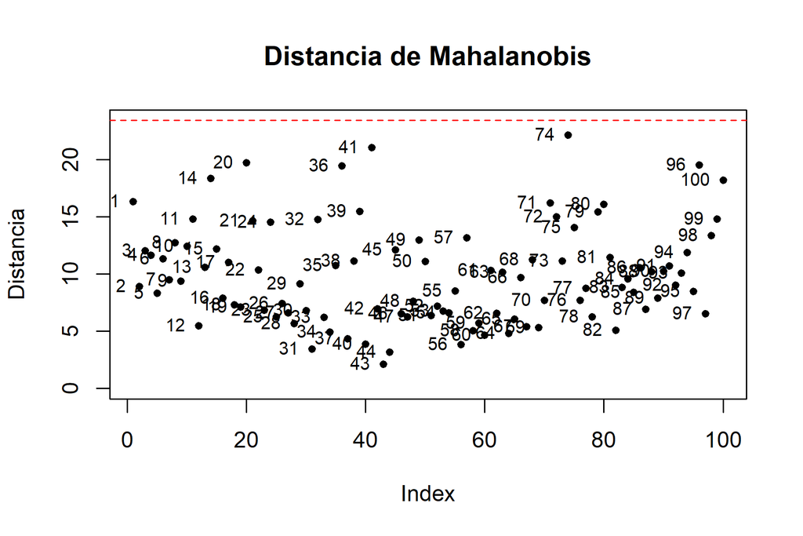

Distancia de Mahalanobis para detección de outliers

```r
# Cálculo de distancia de Mahalanobis
ma <- mahalanobis(datos_cl,
                  apply(datos_cl, 2, mean, na.rm = TRUE),
                  cov(datos_cl, use = "na.or.complete"))

k <- dim(datos_cl)[2]  # Número de variables
Lim <- k + 3 * sqrt(k * 2)  # Límite distancia de Mahalanobis

# Gráfico
plot(ma, pch = 20, ylim = c(0, max(ma, Lim, na.rm = TRUE)),
     main = "Distancia de Mahalanobis",
     xlab = "Index", ylab = "Distancia")
text(ma, rownames(datos_cl), pos = 2, cex = 0.8)
abline(h = Lim, col = "red", lty = 2)
```

Se observa como ninguno de los individuos muestra una distancia por encima del umbral, por lo que no parece haber ningún outlier muy pronunciado.

## Análisis de Escalas

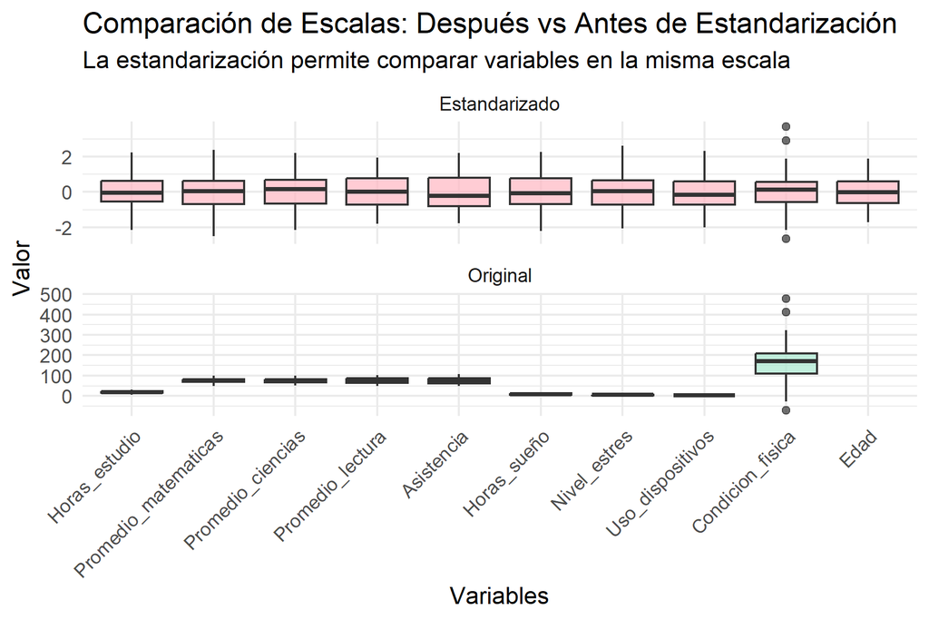

Comparación antes y después de la estandarización

```r
# Estandarización de datos
datos_st <- as.data.frame(scale(datos_cl, center = TRUE, scale = TRUE))

# Datos originales
datos_original <- datos_b[,c(-1,-11)]
datos_original_long <- stack(datos_original)
datos_original_long$tipo <- "Original"

# Datos estandarizados
datos_st_long <- stack(datos_st)
datos_st_long$tipo <- "Estandarizado"

# Combinar datos
datos_combined <- rbind(
      data.frame(Variable = datos_original_long$ind,
             Valor = datos_original_long$values,
             Tipo = "Original"),
      data.frame(Variable = datos_st_long$ind,
             Valor = datos_st_long$values,
             Tipo = "Estandarizado")
  )

# Gráfico comparativo
ggplot(datos_combined, aes(x = Variable, y = Valor, fill = Tipo)) +
  geom_boxplot(alpha = 0.7) +
  facet_wrap(~Tipo, scales = "free_y", ncol = 1) +
  scale_fill_manual(values = c("Original" = "#A8E6CF", "Estandarizado" = "#FFB6C1")) +
  theme(axis.text.x = element_text(angle = 45, hjust = 1),
        legend.position = "none") +
  labs(title = "Comparación de Escalas: Después vs Antes de Estandarización",
       subtitle = "La estandarización permite comparar variables en la misma escala",
       x = "Variables", y = "Valor")
```

Debido a la naturaleza de los datos, ya que diversas variables están en escalas que difieren de forma notable, se propone realizar una estandarización de dichos datos previo al análisis.

La **estandarización** transforma todas las variables a una escala común (media = 0, desviación estándar = 1), permitiendo que variables con diferentes rangos (ej: condición física vs. horas de estudio) sean comparables en el análisis de clustering dándoles la misma relevancia en el Análisis de Componentes Principales.

# 🌳 Análisis de Clustering Jerárquico

Se realizará un análisis de agrupamiento jerárquico utilizando la distancia euclídea para hallar los posibles clusters.

```r
# Matriz de distancias
D <- dist(datos_st)

# Diferentes métodos de clustering
hc.ward <- hclust(D, method = "ward.D2")
hc.avg <- hclust(D, method = "average")
hc.complete <- hclust(D, method = "complete")
hc.single <- hclust(D, method = "single")
```

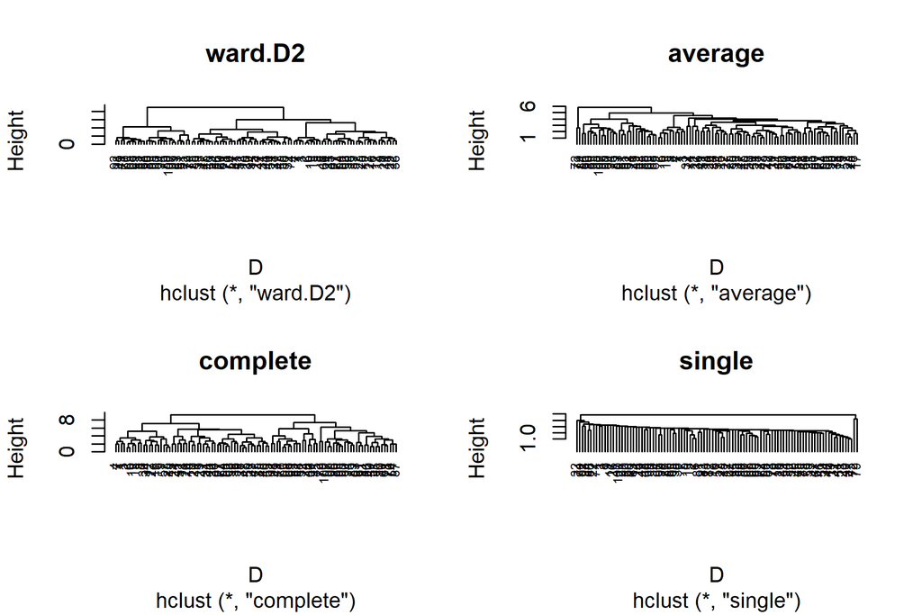

```r
# Visualización de dendrogramas
par(mfrow = c(2,2))
plot(hc.ward, main = "ward.D2", hang = -1, cex = 0.6)
plot(hc.avg, main = "average", hang = -1, cex = 0.6)
plot(hc.complete, main = "complete", hang = -1, cex = 0.6)
plot(hc.single, main = "single", hang = -1, cex = 0.6)
```

```r
par(mfrow = c(1,1))
```

Los **dendrogramas** muestran cómo se agrupan los estudiantes según cada método:

- **Ward.D2**: Muestra clusters equilibrados y bien definidos
- **Average**: Presenta buena separación pero con algunos individuos muy alejados
- **Complete**: Clusters más compactos pero menos balanceados
- **Single**: Tendencia a crear cadenas largas (menos útil para este análisis)

## Evaluación de Métodos

```r
# Cálculo de correlaciones cofenéticas
methods <- c("ward.D2", "average", "complete", "single")
c_coef <- sapply(methods, function(m) {
    hc <- hclust(D, method = m)
    cor(cophenetic(hc), D)
})
names(c_coef) <- methods

# Tabla de resultados ordenada de mayor a menor
resultado_metodos <- data.frame(
  Método = names(c_coef),
  Correlación_Cofenética = round(c_coef, 4)
) %>%
  arrange(desc(Correlación_Cofenética))

kable(resultado_metodos,
      caption = "Evaluación de métodos de clustering (ordenado de mejor a peor)") %>%
  kable_styling(bootstrap_options = c("striped", "hover")) %>%
  row_spec(1, bold = TRUE, color = "white", background = "#28a745") %>%  # Verde para el mejor
  row_spec(2, bold = TRUE, color = "white", background = "#ffc107")     # Amarillo para el seleccionado
```

Evaluación de métodos de clustering (ordenado de mejor a peor)

|  | Método | Correlación_Cofenética |
| --- | --- | --- |
| average | average | 0.6019 |
| ward.D2 | ward.D2 | 0.5229 |
| complete | complete | 0.5003 |
| single | single | 0.3959 |

Se opta por seleccionar el método **Ward.D2** aunque muestra la segunda mejor correlación cofenética (0.5229). Esta decisión se basa en que el dendrograma de Ward.D2 presenta una **distribución más equilibrada e interpretable** de los clusters comparado con el método **Average**, que aunque tiene mejor correlación cofenética (0.6019), muestra dos individuos muy separados del resto de grupos, creando una estructura menos balanceada. De todos modos se hará un análisis paralelo de ambos métodos para comparar posteriormente los resultados y decidir en base a ellos.

## Determinación del Número Óptimo de Clusters

### Para Ward.D2

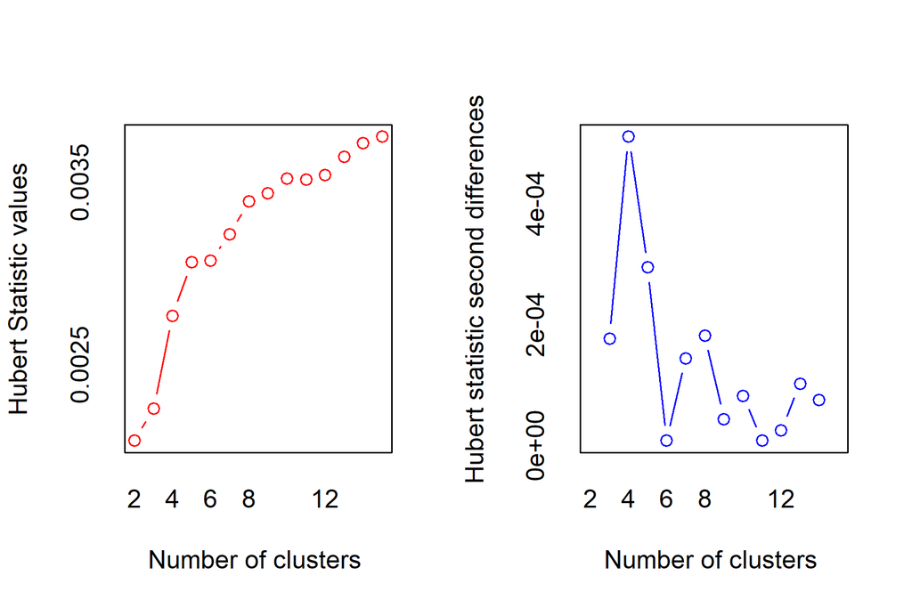

```
## *** : The Hubert index is a graphical method of determining the number of clusters.
##                 In the plot of Hubert index, we seek a significant knee that corresponds to a
##                 significant increase of the value of the measure i.e the significant peak in Hubert
##                 index second differences plot.
##
```

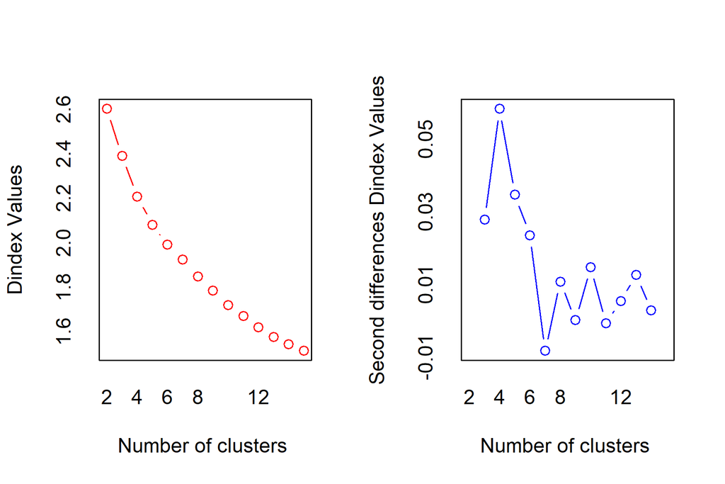

```
## *** : The D index is a graphical method of determining the number of clusters.
##                 In the plot of D index, we seek a significant knee (the significant peak in Dindex
##                 second differences plot) that corresponds to a significant increase of the value of
##                 the measure.
##
## * Among all indices:
## * 6 proposed 2 as the best number of clusters
## * 3 proposed 3 as the best number of clusters
## * 4 proposed 4 as the best number of clusters
## * 3 proposed 5 as the best number of clusters
## * 1 proposed 8 as the best number of clusters
## * 5 proposed 13 as the best number of clusters
## * 1 proposed 14 as the best number of clusters
## * 1 proposed 15 as the best number of clusters
##
##                    ***** Conclusion *****
##
## * According to the majority rule, the best number of clusters is  2
##
##
```

```r
# Determinación automática del número de clusters
nbclust.ward <- NbClust(data = datos_st,
                       diss = NULL,
                       distance = "euclidean",
                       method = "ward.D2")
```

### Para Average

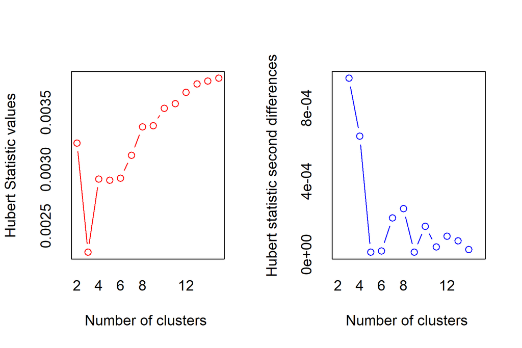

```
## *** : The Hubert index is a graphical method of determining the number of clusters.
##                 In the plot of Hubert index, we seek a significant knee that corresponds to a
##                 significant increase of the value of the measure i.e the significant peak in Hubert
##                 index second differences plot.
##
```

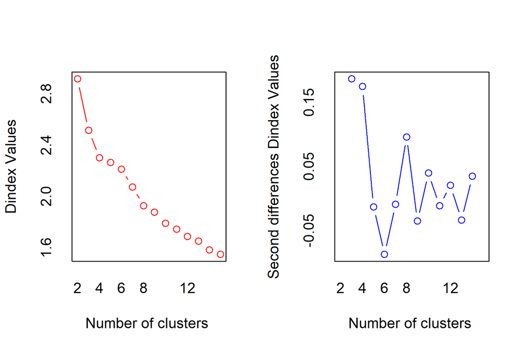

```
## *** : The D index is a graphical method of determining the number of clusters.
##                 In the plot of D index, we seek a significant knee (the significant peak in Dindex
##                 second differences plot) that corresponds to a significant increase of the value of
##                 the measure.
##
## * Among all indices:
## * 6 proposed 2 as the best number of clusters
## * 8 proposed 3 as the best number of clusters
## * 5 proposed 4 as the best number of clusters
## * 2 proposed 8 as the best number of clusters
## * 3 proposed 15 as the best number of clusters
##
##                    ***** Conclusion *****
##
## * According to the majority rule, the best number of clusters is  3
##
##
```

```r
nbclust.average <- NbClust(data = datos_st,
                          diss = NULL,
                          distance = "euclidean",
                          method = "average")
```

### Resultados

La función `NbClust()` evalúa múltiples criterios estadísticos para determinar el número óptimo de clusters:

- **Método Ward**: La mayoría de índices sugieren **2 clusters** como solución óptima.
- **Método Average**: Los criterios indican **3 clusters** como la mejor segmentación.

Esta evaluación automática se basa en 24 índices diferentes (Hubert, D-index, Silhouette, etc.) que analizan la cohesión interna de los grupos y la separación entre ellos.

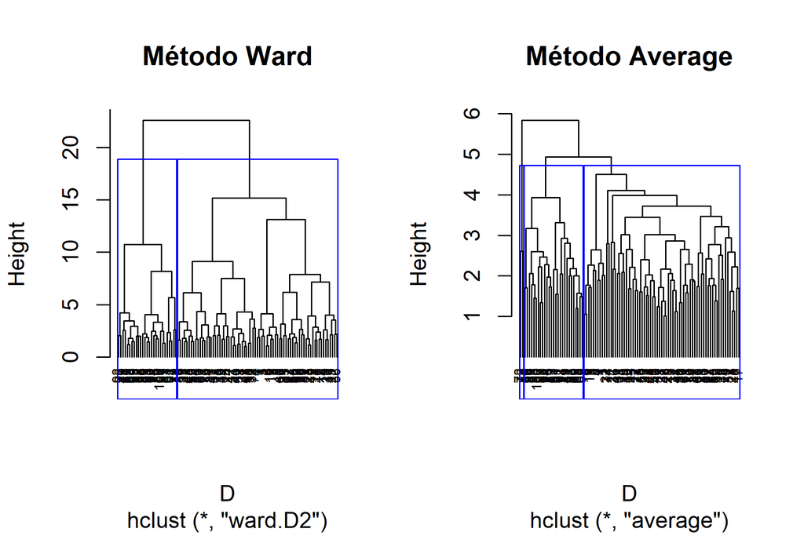

Dendrogramas con clusters seleccionados

```r
par(mfrow = c(1,2))
plot(hc.ward, main = "Método Ward", hang = -1, cex = 0.6)
rect.hclust(hc.ward, k = 2, border = "blue")

plot(hc.avg, main = "Método Average", hang = -1, cex = 0.6)
rect.hclust(hc.avg, k = 3, border = "blue")
```

```r
par(mfrow = c(1,1))
```

Los **rectángulos azules** delimitan los clusters óptimos según cada método:

- **Ward**: Sugiere 2 grupos principales basados en las alturas de corte del dendrograma.
- **Average**: Identifica 3 grupos distintos con uno de ellos compuesto por solamente dos individuos.

# 📐 Análisis de Componentes Principales

```r
# PCA
acp <- princomp(datos_st)
summary(acp)
```

```
## Importance of components:
##                          Comp.1    Comp.2    Comp.3     Comp.4     Comp.5
## Standard deviation     2.226441 1.3256790 1.0979314 0.94615372 0.63977744
## Proportion of Variance 0.500711 0.1775177 0.1217630 0.09042494 0.04134497
## Cumulative Proportion  0.500711 0.6782286 0.7999916 0.89041653 0.93176149
##                            Comp.6    Comp.7     Comp.8      Comp.9     Comp.10
## Standard deviation     0.51316071 0.4316709 0.31634669 0.287802851 0.207320582
## Proportion of Variance 0.02659939 0.0188222 0.01010861 0.008366715 0.004341598
## Cumulative Proportion  0.95836088 0.9771831 0.98729169 0.995658402 1.000000000
```

```r
# Cargas de las componentes principales
round(acp$loadings[,1:2], 3) %>%
  kable(caption = "Cargas de las dos primeras componentes principales") %>%
  kable_styling(bootstrap_options = c("striped", "hover"))
```

Cargas de las dos primeras componentes principales

|  | Comp.1 | Comp.2 |
| --- | --- | --- |
| Edad | 0.001 | 0.212 |
| Horas_estudio | 0.349 | 0.009 |
| Promedio_matematicas | 0.422 | -0.076 |
| Promedio_ciencias | 0.418 | -0.082 |
| Promedio_lectura | 0.356 | -0.063 |
| Asistencia | 0.340 | -0.059 |
| Horas_sueño | 0.319 | 0.103 |
| Nivel_estres | 0.071 | 0.682 |
| Uso_dispositivos | -0.407 | 0.112 |
| Condicion_fisica | 0.105 | 0.669 |

## Visualización con Clusters

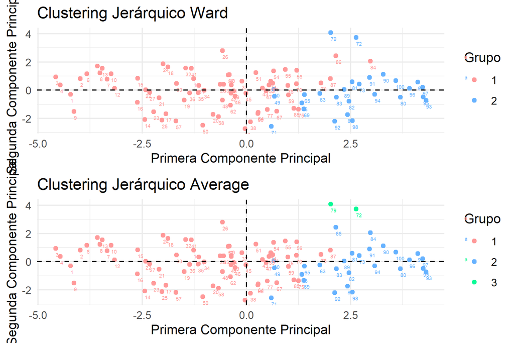

Clustering jerárquico visualizado en el espacio PCA

```r
# Ward con 2 clusters
datos_st$Grupo <- nbclust.ward$Best.partition

df_acp <- data.frame(
  PC1 = acp$scores[,1],
  PC2 = acp$scores[,2],
  Grupo = factor(datos_st$Grupo)
)

p1 <- ggplot(df_acp, aes(x = PC1, y = PC2, color = Grupo)) +
  geom_point(size = 1.5) +
  geom_text(aes(label = rownames(datos_st)), hjust = 0, vjust = 2, size = 1.5) +
  geom_hline(yintercept = 0, linetype = "dashed") +
  geom_vline(xintercept = 0, linetype = "dashed") +
  scale_color_manual(values = c("#FF9999", "#66B2FF")) +
  labs(x = "Primera Componente Principal",
       y = "Segunda Componente Principal") +
  ggtitle("Clustering Jerárquico Ward")

# Average con 3 clusters
datos_st$Grupo <- nbclust.average$Best.partition

df_acp <- data.frame(
  PC1 = acp$scores[,1],
  PC2 = acp$scores[,2],
  Grupo = factor(datos_st$Grupo)
)

p2 <- ggplot(df_acp, aes(x = PC1, y = PC2, color = Grupo)) +
  geom_point(size = 1.5) +
  geom_text(aes(label = rownames(datos_st)), hjust = 0, vjust = 2, size = 1.5) +
  geom_hline(yintercept = 0, linetype = "dashed") +
  geom_vline(xintercept = 0, linetype = "dashed") +
  scale_color_manual(values = c("#FF9999", "#66B2FF", "#09FA97")) +
  labs(x = "Primera Componente Principal",
       y = "Segunda Componente Principal") +
  ggtitle("Clustering Jerárquico Average")

grid.arrange(p1, p2, ncol = 1)
```

Los **gráficos PCA** proyectan los clusters en un espacio bidimensional donde:

- **Eje X (CP1)**: Rendimiento académico (derecha = mejor rendimiento).
- **Eje Y (CP2)**: Combinación de condición física y estrés (arriba = alta condición física + alto estrés).
- **Colores**: Representan los diferentes grupos identificados.
- **Líneas punteadas**: Marcan los valores promedio (punto de referencia)

## Interpretación de Componentes

En cuanto al gráfico obtenido, se puede apreciar como hay dos grupos principales en ambos métodos con ciertas variaciones de individuos que se encuentran más centrados en el gráfico.

**Primera Componente Principal (CP1)**: Parece tener que ver con el rendimiento académico (correlación positiva con Promedios en asignaturas) y buenos hábitos de estudio (correlaciones positivas con Horas de sueño, Horas de estudio y Asistencia, correlación negativa con Uso de Dispositivos).

**Segunda Componente Principal (CP2)**: Propone una diferenciación compleja relacionada con aspectos físicos y emocionales contradictorios donde valores altos indican simultáneamente alta Condición Física (positivo) y alto Nivel de Estrés (negativo).

# 🔧 Análisis con Outliers Eliminados

Se observa que algunos individuos atípicos (individuos 72 y 79) corresponden a los valores más altos en la variable Condición Física. Se realizará el análisis eliminando estos outliers.

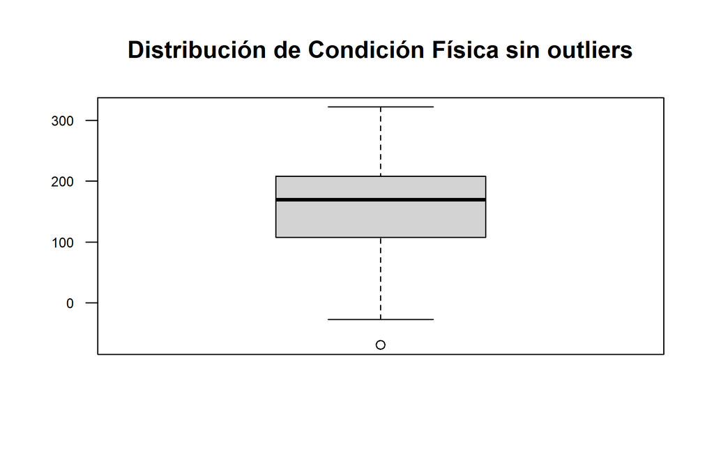

```r
# Eliminación de outliers específicos
datos_2 <- datos_b[c(-72, -79),]
boxplot(datos_2[,10], las = 2, cex.axis = 0.7,
        main = "Distribución de Condición Física sin outliers")
```

```r
# Nuevo análisis
datos_2 <- datos_2[,-11]
datos_st_new <- as.data.frame(scale(datos_2, center = TRUE, scale = TRUE))

D_new <- dist(datos_st_new)
hc.avg_new <- hclust(D_new, method = "average")

# Evaluación de métodos sin outliers
methods <- c("ward.D2", "average", "complete", "single")
c_coef_new <- sapply(methods, function(m) {
    hc <- hclust(D_new, method = m)
    cor(cophenetic(hc), D_new)
})

# Tabla de resultados ordenada de mayor a menor
resultado_metodos_new <- data.frame(
  Método = names(c_coef_new),
  Correlación_Cofenética = round(c_coef_new, 4)
) %>%
  arrange(desc(Correlación_Cofenética))

kable(resultado_metodos_new,
      caption = "Evaluación de métodos sin outliers (ordenado de mejor a peor)") %>%
  kable_styling(bootstrap_options = c("striped", "hover")) %>%
  row_spec(1, bold = TRUE, color = "white", background = "#28a745")
```

Evaluación de métodos sin outliers (ordenado de mejor a peor)

|  | Método | Correlación_Cofenética |
| --- | --- | --- |
| average | average | 0.5655 |
| ward.D2 | ward.D2 | 0.5152 |
| complete | complete | 0.5114 |
| single | single | 0.3602 |

El método **average** muestra ahora la mejor correlación cofenética (0.5655), por lo que se selecciona como el más adecuado.

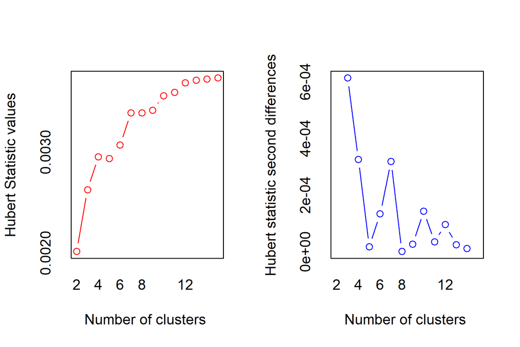

```
## *** : The Hubert index is a graphical method of determining the number of clusters.
##                 In the plot of Hubert index, we seek a significant knee that corresponds to a
##                 significant increase of the value of the measure i.e the significant peak in Hubert
##                 index second differences plot.
##
```

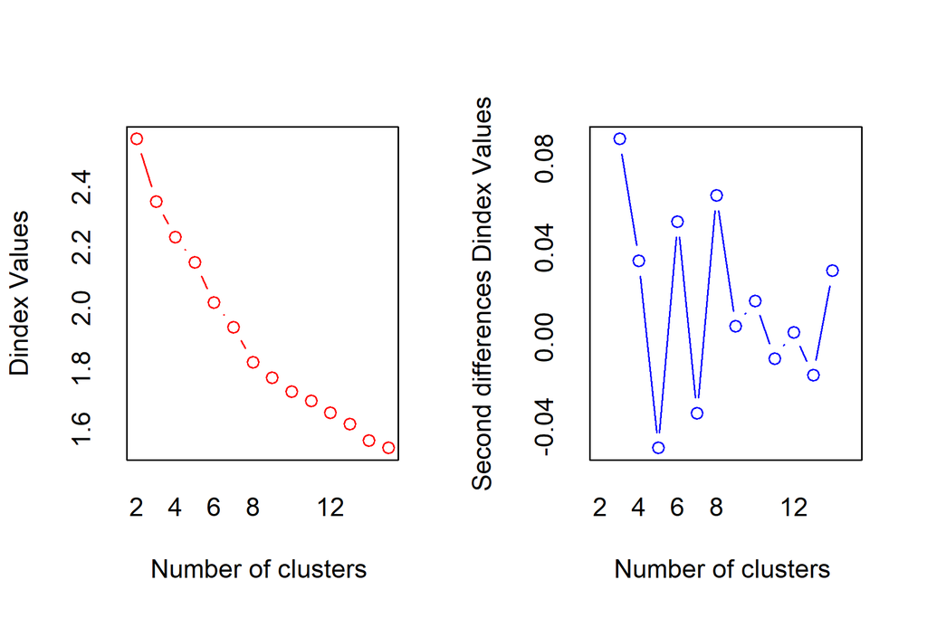

```
## *** : The D index is a graphical method of determining the number of clusters.
##                 In the plot of D index, we seek a significant knee (the significant peak in Dindex
##                 second differences plot) that corresponds to a significant increase of the value of
##                 the measure.
##
## * Among all indices:
## * 4 proposed 2 as the best number of clusters
## * 8 proposed 3 as the best number of clusters
## * 1 proposed 5 as the best number of clusters
## * 1 proposed 6 as the best number of clusters
## * 3 proposed 8 as the best number of clusters
## * 1 proposed 10 as the best number of clusters
## * 1 proposed 11 as the best number of clusters
## * 1 proposed 12 as the best number of clusters
## * 3 proposed 15 as the best number of clusters
##
##                    ***** Conclusion *****
##
## * According to the majority rule, the best number of clusters is  3
##
##
```

```r
# Número óptimo de clusters sin outliers
nbclust.average_new <- NbClust(data = datos_st_new,
                              diss = NULL,
                              distance = "euclidean",
                              method = "average")
```

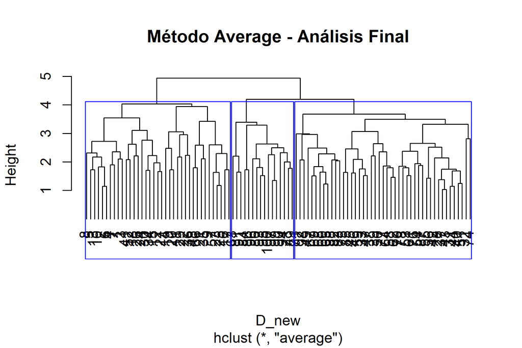

Dendrograma final con método Average

```r
plot(hc.avg_new, main = "Método Average - Análisis Final", hang = -1)
rect.hclust(hc.avg_new, k = 3, border = "blue")
```

# 📈 Resultados Finales

```r
# PCA del análisis refinado
acp_final <- princomp(datos_st_new)
acp_final$loadings[,1] <- -1 * acp_final$loadings[,1]  # Ajuste de orientación

# Cargas finales
round(acp_final$loadings[,1:2], 3) %>%
  kable(caption = "Cargas de componentes principales - Análisis final") %>%
  kable_styling(bootstrap_options = c("striped", "hover"))
```

Cargas de componentes principales - Análisis final

|  | Comp.1 | Comp.2 |
| --- | --- | --- |
| Edad | -0.014 | 0.107 |
| Horas_estudio | 0.353 | 0.108 |
| Promedio_matematicas | 0.423 | -0.047 |
| Promedio_ciencias | 0.420 | -0.067 |
| Promedio_lectura | 0.356 | -0.144 |
| Asistencia | 0.340 | -0.139 |
| Horas_sueño | 0.320 | 0.206 |
| Nivel_estres | 0.043 | 0.667 |
| Uso_dispositivos | -0.409 | 0.088 |
| Condicion_fisica | 0.078 | 0.660 |

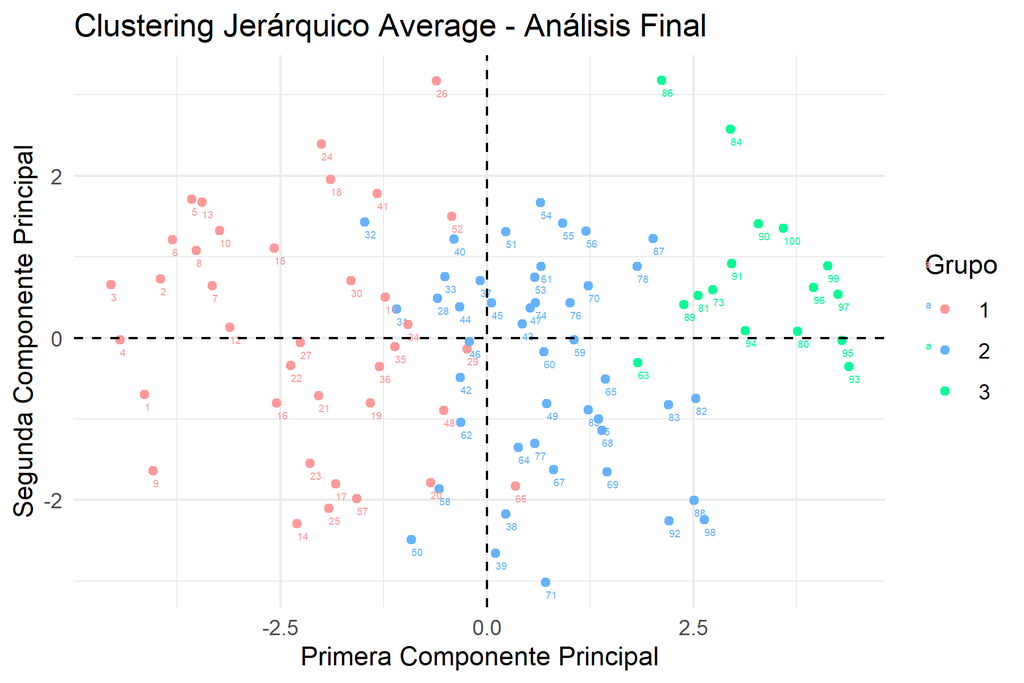

Segmentación final de estudiantes

```r
datos_st_new$Grupo <- nbclust.average_new$Best.partition

df_acp_final <- data.frame(
  PC1 = -1 * acp_final$scores[,1],
  PC2 = acp_final$scores[,2],
  Grupo = factor(datos_st_new$Grupo)
)

ggplot(df_acp_final, aes(x = PC1, y = PC2, color = Grupo)) +
  geom_point(size = 1.5) +
  geom_text(aes(label = rownames(datos_st_new)), hjust = 0, vjust = 2, size = 1.5) +
  geom_hline(yintercept = 0, linetype = "dashed") +
  geom_vline(xintercept = 0, linetype = "dashed") +
  scale_color_manual(values = c("#FF9999", "#66B2FF", "#09FA97")) +
  labs(x = "Primera Componente Principal",
       y = "Segunda Componente Principal") +
  ggtitle("Clustering Jerárquico Average - Análisis Final")
```

El **gráfico final** muestra la segmentación definitiva donde se observa claramente:

- **Grupo 1 (Rojo)**: Concentrado en la zona izquierda (bajo rendimiento académico).
- **Grupo 2 (Azul)**: Disperso en el centro con tendencia variable en CP2 (rendimiento medio).
- **Grupo 3 (Verde)**: Ubicado en la zona derecha con valores diversos en CP2 (alto rendimiento académico)

# 👥 Caracterización de Grupos Identificados

En cuanto a los grupos obtenidos, se puede observar como estos se dividen según el rendimiento académico (CP1) principalmente.

```r
# Resumen por grupos
grupo_summary <- datos_st_new %>%
  group_by(Grupo) %>%
  summarise(
    N_estudiantes = n(),
    across(everything(), ~ round(mean(.x), 2)),
    .groups = 'drop'
  )

kable(grupo_summary,
      caption = "Características promedio por grupo (valores estandarizados)") %>%
  kable_styling(bootstrap_options = c("striped", "hover")) %>%
  row_spec(1, background = "#FFE6E6") %>%  # Rojo claro para Grupo 1
  row_spec(2, background = "#E6F3FF") %>%  # Azul claro para Grupo 2
  row_spec(3, background = "#E6FFE6")     # Verde claro para Grupo 3
```

Características promedio por grupo (valores estandarizados)

| Grupo | N_estudiantes | Edad | Horas_estudio | Promedio_matematicas | Promedio_ciencias | Promedio_lectura | Asistencia | Horas_sueño | Nivel_estres | Uso_dispositivos | Condicion_fisica |
| --- | --- | --- | --- | --- | --- | --- | --- | --- | --- | --- | --- |
| 1 | 37 | -0.05 | -0.85 | -0.93 | -0.93 | -0.81 | -0.75 | -0.58 | -0.09 | 0.93 | -0.09 |
| 2 | 45 | 0.17 | 0.31 | 0.29 | 0.30 | 0.30 | 0.21 | 0.01 | -0.16 | -0.34 | -0.23 |
| 3 | 16 | -0.37 | 1.11 | 1.32 | 1.33 | 1.02 | 1.16 | 1.31 | 0.65 | -1.18 | 0.85 |

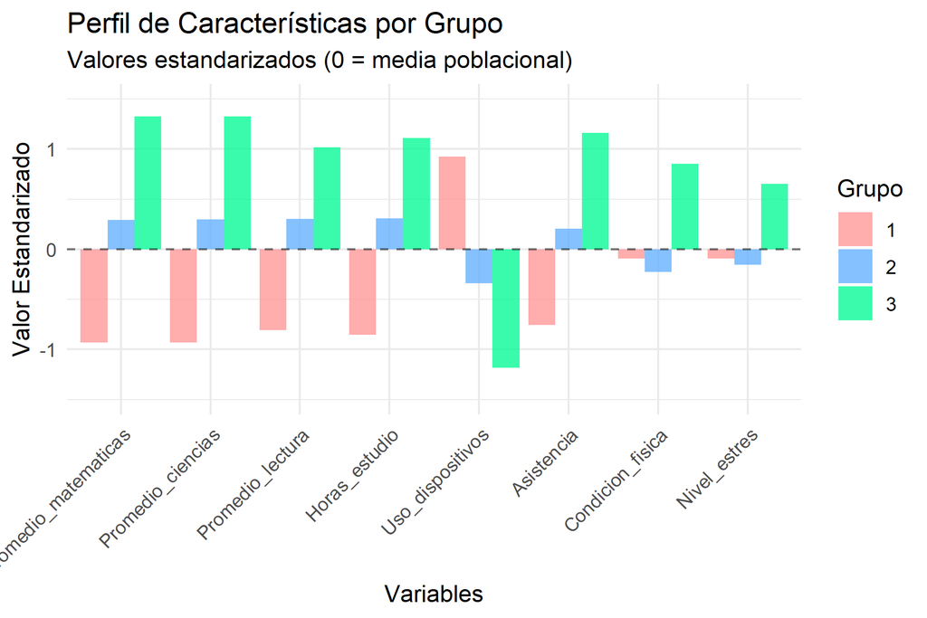

Perfil de características por grupo

```r
# Gráfico de radar/perfil por grupo

# Seleccionar variables clave para caracterización
vars_clave <- c("Promedio_matematicas", "Promedio_ciencias", "Promedio_lectura",
                "Horas_estudio", "Uso_dispositivos", "Asistencia", "Condicion_fisica", "Nivel_estres")

perfil_grupos <- datos_st_new %>%
  select(Grupo, all_of(vars_clave)) %>%
  group_by(Grupo) %>%
  summarise(across(everything(), mean), .groups = 'drop') %>%
  melt(id.vars = "Grupo", variable.name = "Variable", value.name = "Valor")

# Gráfico de barras agrupadas
ggplot(perfil_grupos, aes(x = Variable, y = Valor, fill = factor(Grupo))) +
  geom_bar(stat = "identity", position = "dodge", alpha = 0.8) +
  scale_fill_manual(values = c("1" = "#FF9999", "2" = "#66B2FF", "3" = "#09FA97"),
                    name = "Grupo") +
  geom_hline(yintercept = 0, linetype = "dashed", alpha = 0.5) +
  theme(axis.text.x = element_text(angle = 45, hjust = 1)) +
  labs(title = "Perfil de Características por Grupo",
       subtitle = "Valores estandarizados (0 = media poblacional)",
       x = "Variables", y = "Valor Estandarizado") +
  coord_cartesian(ylim = c(-1.5, 1.5))
```

El **gráfico de barras** compara los grupos en variables clave donde:

- **Línea horizontal (0)**: Representa la media de toda la población.
- **Barras positivas**: Por encima de la media poblacional.
- **Barras negativas**: Por debajo de la media poblacional.

## 🔴 Grupo 1: Estudiantes con Bajo Rendimiento

**Características principales:**

- 📉 **Rendimiento académico**: Por debajo de la media en todas las asignaturas.
- 📚 **Hábitos de estudio**: Menor dedicacón en horas de estudio y asistencia a clases, a la vez que mayor uso de dispositivos electrónicos junto con menor horas de sueño.
- 🎯 **Patrón identificativo**: Valores negativos consistentes en CP1 (rendimiento académico).
- 📊 **Dispersión**: Comportamiento variable en CP2 (aspectos físicos/emocionales)

## 🟢 Grupo 3: Estudiantes de Alto Rendimiento Integral

**Características principales:**

- 🌟 **Rendimiento académico**: Bastante por encima de la media en todas las áreas.
- 💪 **Perfil complejo**: Buen rendimiento académico con patrones diversos en condición física y estrés.
- **🎯 Patrón identificativo**: Valores positivos en CP1 con tendencia positiva en CP2.
- 🏆 **Excelencia académica**: Destacan principalmente en rendimiento académico.

```r
# Tabla de criterios de clasificación
criterios_clasificacion <- data.frame(
  Criterio = c("Rendimiento Académico/Hábitos (CP1)", "Condición Física/Estrés (CP2)", "Posición en Gráfico PCA"),
  "Grupo 1" = c("< -0.5 (Bajo)", "Variable", "Lado izquierdo"),
  "Grupo 2" = c("-0.5 a 0.5 (Medio)", "Tendencia ligeramente negativa", "Centro"),
  "Grupo 3" = c("> 0.5 (Alto)", "Tendencia positiva", "Lado derecho"),
  check.names = FALSE
)

kable(criterios_clasificacion,
      caption = "Criterios de Clasificación de Estudiantes",
      align = "lccc") %>%
  kable_styling(bootstrap_options = c("striped", "hover")) %>%
  column_spec(2, background = "#FFE6E6") %>%  # Grupo 1 - rojo claro
  column_spec(3, background = "#E6F3FF") %>%  # Grupo 2 - azul claro
  column_spec(4, background = "#E6FFE6")     # Verde claro para Grupo 3
```

Criterios de Clasificación de Estudiantes

| Criterio | Grupo 1 | Grupo 2 | Grupo 3 |
| --- | --- | --- | --- |
| Rendimiento Académico/Hábitos (CP1) | < -0.5 (Bajo) | -0.5 a 0.5 (Medio) | > 0.5 (Alto) |
| Condición Física/Estrés (CP2) | Variable | Tendencia ligeramente negativa | Tendencia positiva |
| Posición en Gráfico PCA | Lado izquierdo | Centro | Lado derecho |

## Resumen de Identificación

La clasificación de estudiantes se basa principalmente en la **Primera Componente Principal (CP1)**, que representa el rendimiento académico general, complementada por la **Segunda Componente Principal (CP2)**, que refleja una combinación compleja de condición física y nivel de estrés.

**Regla de clasificación simplificada:**

1. **Calcular CP1** (combinación de promedios académicos y hábitos de estudio y de bienestar)
2. **Evaluar CP2** (equilibrio entre condición física y nivel de estrés)
3. **Aplicar umbrales** en el espacio bidimensional PCA
4. **Asignar grupo** según la posición en el gráfico de componentes principales

# 📋 Conclusiones

El análisis de clustering ha permitido identificar **tres grupos distintos de estudiantes** con características diferenciadas en términos de rendimiento académico y patrones físicos/emocionales.

## Hallazgos Principales

✅ **Método óptimo identificado**: El método Average con correlación cofenética de 0.5655 resultó ser el más adecuado tras la eliminación de outliers.

✅ **Tres perfiles claramente diferenciados**: La segmentación reveló grupos con características distintivas y interpretables.

✅ **Componentes principales interpretables**:

- CP1 representa el rendimiento académico general y hábitos estudiantiles y de bienestar.
- CP2 refleja una combinación compleja de condición física y estrés